# Identifying Unusual Points in Regression

SDS 291

March 2, 2020

# Outliers, Leverage, and Influence

**Outliers:** Points that do not fit the regression line well, far away vertically from other points

- These affect the error
- We deal with them in the residual
  - Standardized residuals: standardize the residuals by subtracting the mean residual
  - Studentized residuals: take out the point in question and re-estimate the residuals

**Leverage:** how much a point draws the slope of the regression toward that point

- We calculate the leverage statistic $h_i$ to quantify how much leverage these points have on the regression line

**Influence:** Combines concepts of both leverage and outliers

- Broadly, how much impact a particular case has on the estimated regression equation
- Depends on how close the trend lies to the trend of the rest of the data (i.e., residuals) *and* its leverage.
- Cook’s Distance quantifies how much a given point influences the regression fit

# Identifying Unusual Points in Regression

| Statistic | Moderately Unusual | Very Unusual |
| --- | --- | --- |
| Standardized Residual | beyond $\pm$ 2 | beyond $\pm$ 3 |
| Studentized Residual | beyond $\pm$ 2 | beyond $\pm$ 3 |
| Levereage, $h_i$ | $>(2(k+1))/n$ | $>(3(k+1))/n$ |
| Cook’s D | >0.5 | >1.0 |

# Outliers

We’re interested in the whether the average distance to win a gold medal increases over time. In other words, are the athelete’s getting better over time?

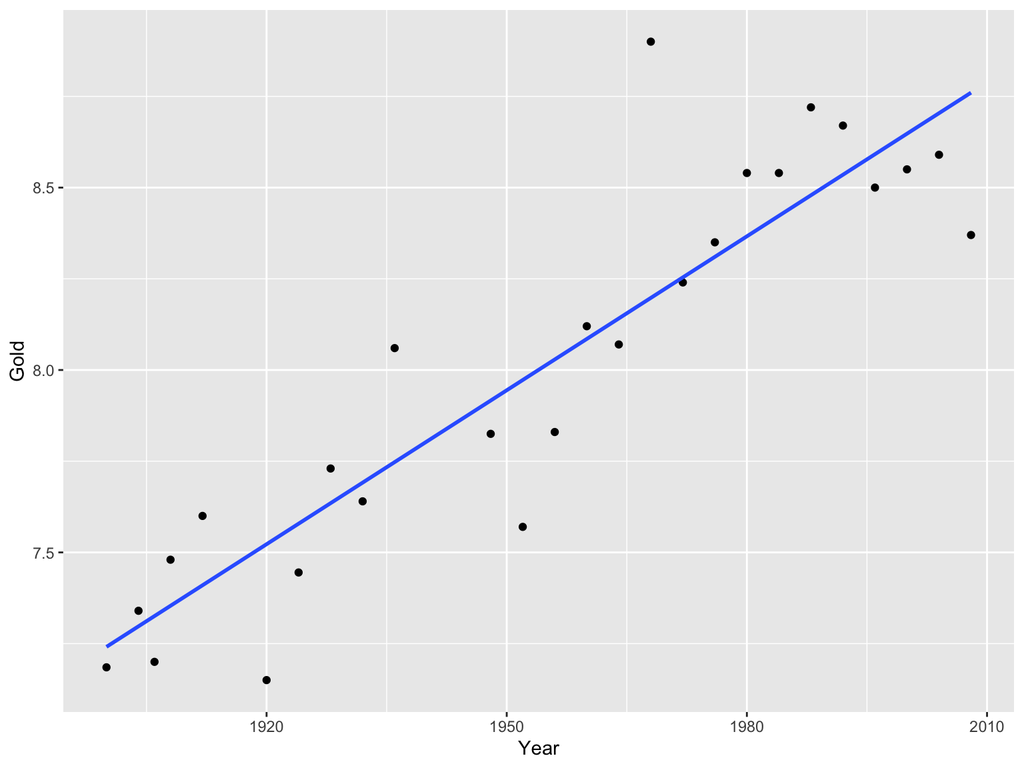

```
##
## Call:
## lm(formula = Gold ~ Year, data = LongJumpOlympics)
##
## Residuals:
##      Min       1Q   Median       3Q      Max
## -0.40256 -0.10991 -0.03256  0.12408  0.70239
##
## Coefficients:
##               Estimate Std. Error t value Pr(>|t|)
## (Intercept) -19.483595   2.689700  -7.244 1.75e-07 ***
## Year          0.014066   0.001376  10.223 3.19e-10 ***
## ---
## Signif. codes:  0 '***' 0.001 '**' 0.01 '*' 0.05 '.' 0.1 ' ' 1
##
## Residual standard error: 0.2375 on 24 degrees of freedom
## Multiple R-squared:  0.8132, Adjusted R-squared:  0.8055
## F-statistic: 104.5 on 1 and 24 DF,  p-value: 3.192e-10
```

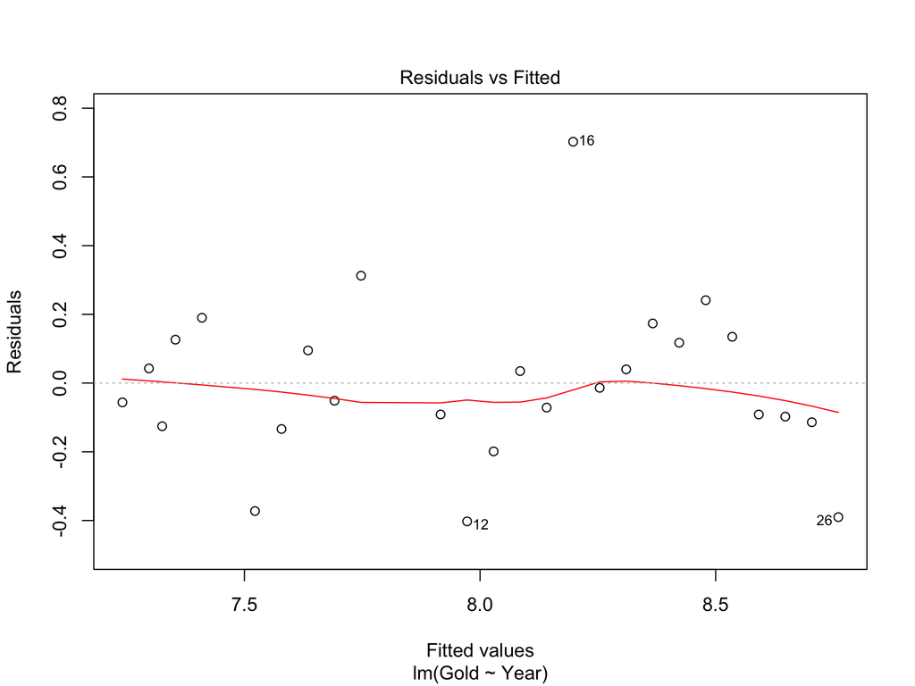

# What are residuals?

- Raw residuals: $y-\hat{y}$

Is a residual of 2.6 big or small?

# What are standardized residuals?

### What’s the standard normal distribution?

- If X has mean $\mu$ and std. dev. $\sigma$, then $\frac{X-\mu}{\sigma}$ has mean = 0 and SD = 1 (i.e., $\sim N(0,1)$)

### Standardized residuals

- Standardized residuals: $\frac{y-\hat{y}}{\hat{\sigma_\epsilon}}$
- Values $\pm$ 2 (moderately unusual) or $\pm$ 3 (very unusual)

Let’s look at the standardized residual:

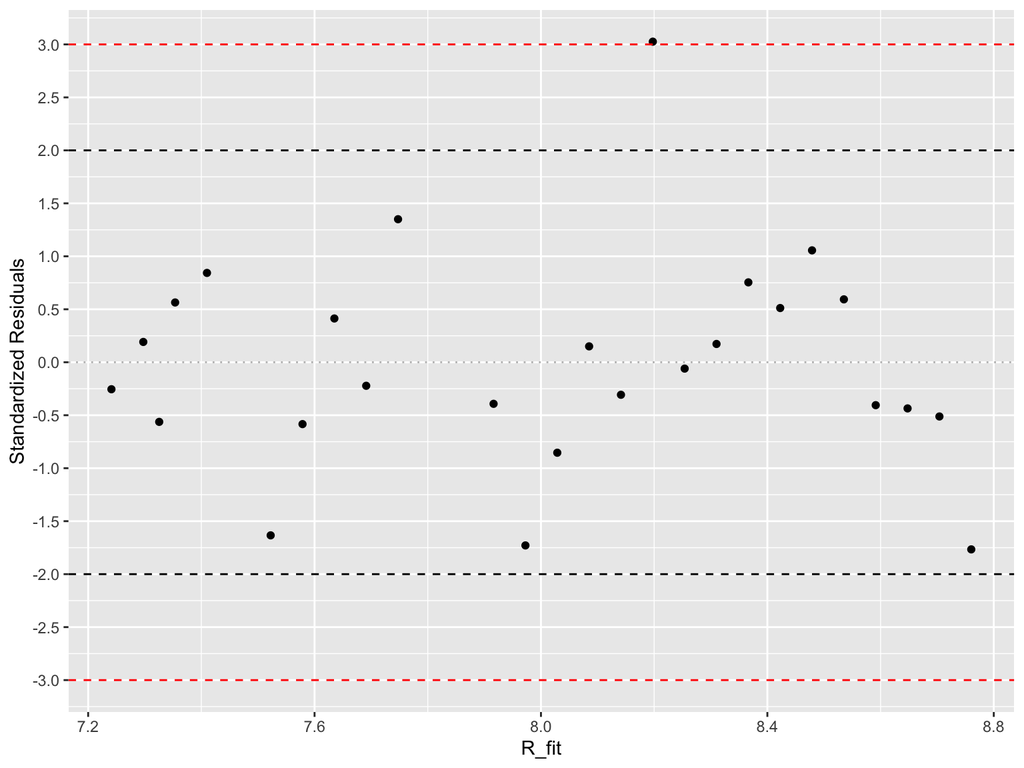

# Leverage

### 2000 Election

In the 2000 Presidential Election, Palm Beach County had an uncommon ballot type that became the subject of much speculation after the outcome of the election wherein President George W Bush won. Critics of the ballot type claimed voters accidentally voted for Buchanan when they intended to vote for another candidate on the ballot. To assess this claim empirically, we can see exactly how unusual Palm Beach County was relative to other counties its state (Florida).

# Looking Visually at the Regression Lines with and without Questionnable Counties

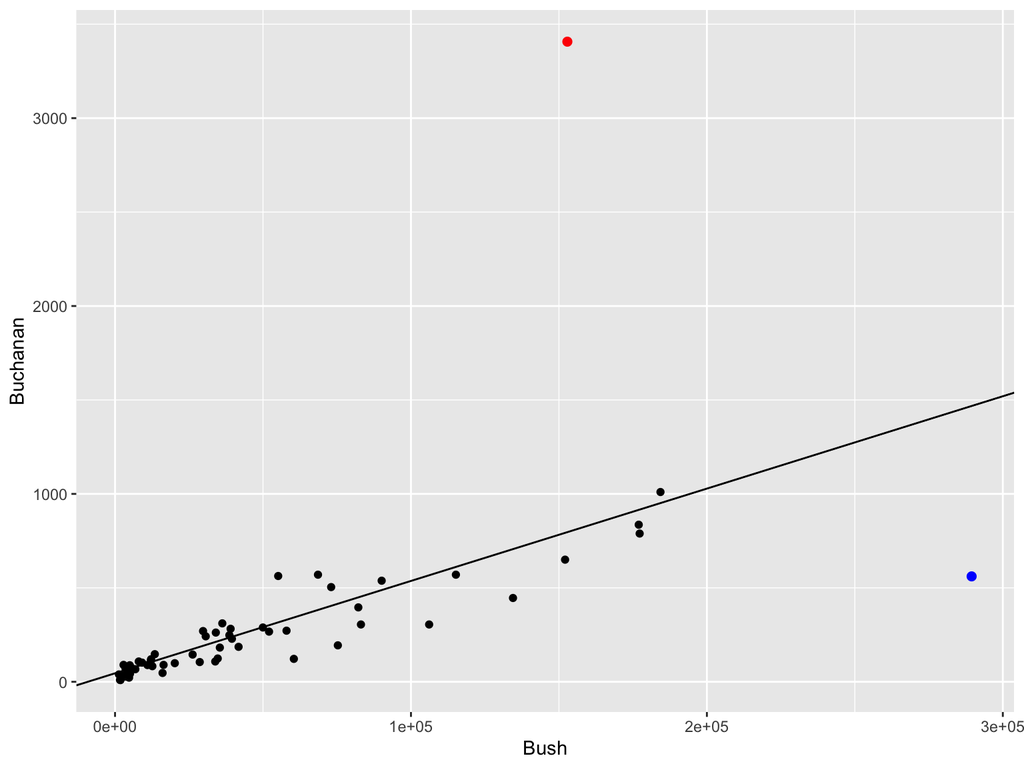

# What if we remove Palm Beach County?

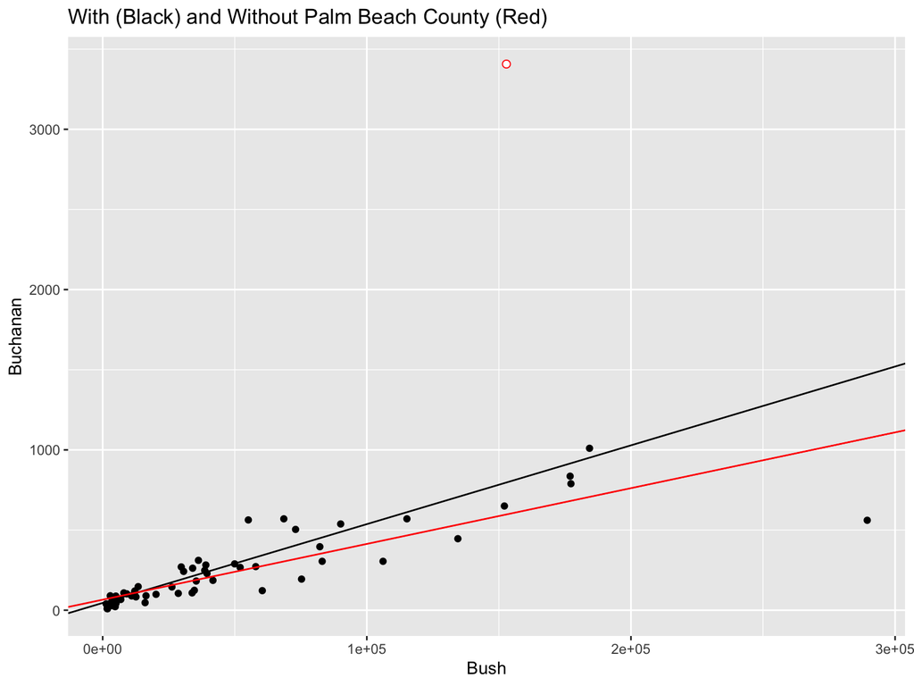

# What if we remove Dade County?

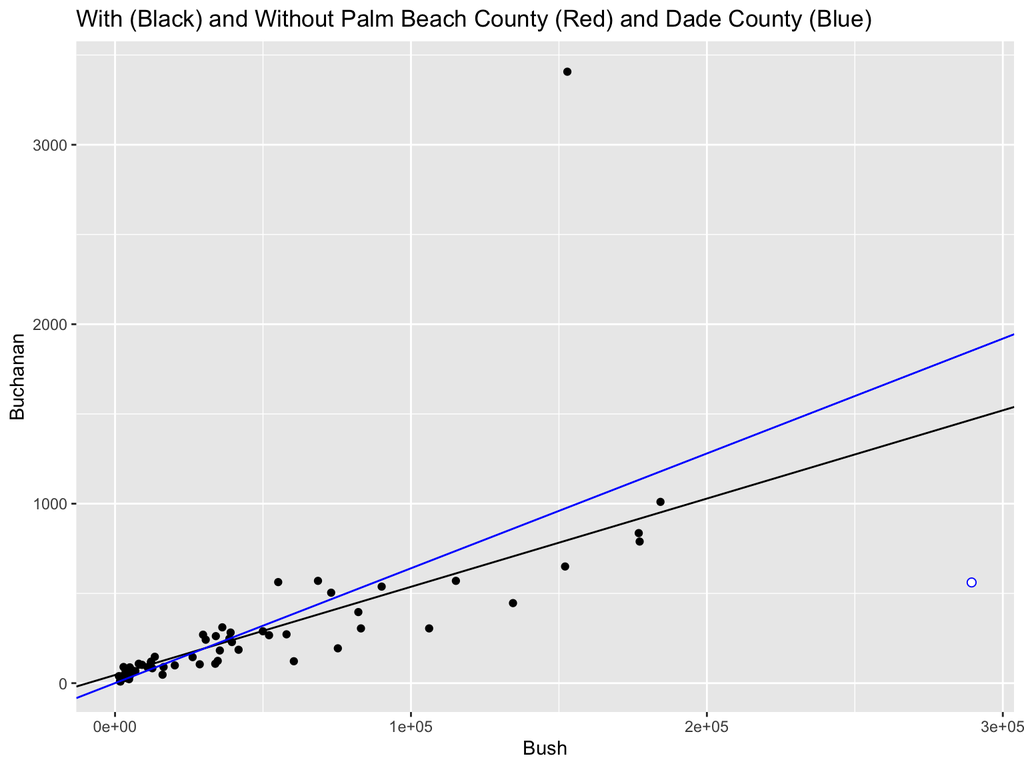

# What if we remove both?

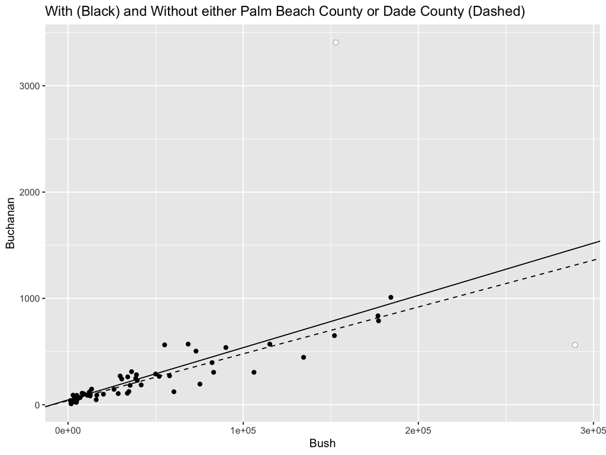

# Leverage

- Points far from the mean value of the predictor ($\bar{x}$)
  - For SLR, quantified leverage could just be distance from mean
    - But that’s not very generalizable to MLR
- In SLR:
  - For a given observation $i$, leverage in SLR is $h_i = \frac{1}{n} + \frac{(x_i - \bar{x})^2}{\sum(x_i - \bar{x})^2}$
  - The sum of all leverage ($\sum h_i$) is 2
  - “Typical” leverage is 2/n, moderately unusual is $h_i>4/n$, and very unusual is $h_i>6/n$
- In MLR:
  - Leverage points have unusual values for any individual or combination of predictors
  - No simple equation, but can be calculated
  - They can influence the regression fit
  - The sum of all leverage is $\sum h_i = k+1$
  - “Typical” leverage is $(k+1)/n$, moderately unusual is $> 2(k+1)/n$, and very unusual is $>3(k+1)/n$

# Leverage - Butterfly Ballots Example

```r
data("PalmBeach") #bringing in the data
PB_lm<-lm(Buchanan~Bush, data=PalmBeach) #fitting the regression model
PB_diag<-ls.diag(PB_lm) #using the least squares diagnostic (ls.diag) function to calculate the leverage and standardized residuals
h_i<-PB_diag$hat
county_lev<-cbind(PalmBeach,h_i)
```

We also want to know the average value of our `x` variable: $\overline{Bush} =$ 4.335576110^{4}

which we depict with a yellow vertical line:

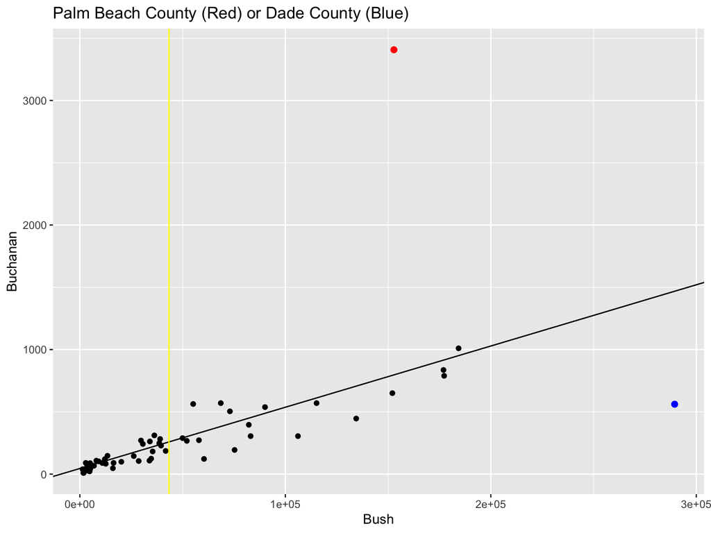

To list the counties with moderate or very unusual values of `x`, or number of Bush votes:

```r
k<-1 #SLR - 1 slope term
n<-67 #67 counties
county_lev %>%
  mutate(m_unusual=ifelse(h_i>(2*(k+1)/n),"y","n"),
         v_unusual=ifelse(h_i>(3*(k+1)/n),"y","n"),
         typ_lev=(k+1)/n,
         pct_typ_lev=h_i/typ_lev) %>%
  filter(m_unusual=="y")
```

```
##         County Buchanan   Bush        h_i m_unusual v_unusual    typ_lev
## 1      BROWARD      789 177279 0.09859725         y         y 0.02985075
## 2         DADE      561 289456 0.29747301         y         y 0.02985075
## 3        DUVAL      650 152082 0.07007421         y         n 0.02985075
## 4 HILLSBOROUGH      836 176967 0.09820784         y         y 0.02985075
## 5   PALM BEACH     3407 152846 0.07085197         y         n 0.02985075
## 6     PINELLAS     1010 184312 0.10761608         y         y 0.02985075
##   pct_typ_lev
## 1    3.303008
## 2    9.965346
## 3    2.347486
## 4    3.289963
## 5    2.373541
## 6    3.605139
```

We see that there are two counties with only moderately unusual values of x ($h_i>\frac{4}{67}$), or number of Bush votes - Palm Beach and Duval. There are four counties with very unusual values of x ($h_i>\frac{6}{67}$), or number of Bush votes: Broward, Dade, Hillsborough, and Pinellas. Dade County had almost 10 times (9.96) more than the typical leverage values ($\frac{2}{67}$).

To highlight the counties with potential leverage visually:

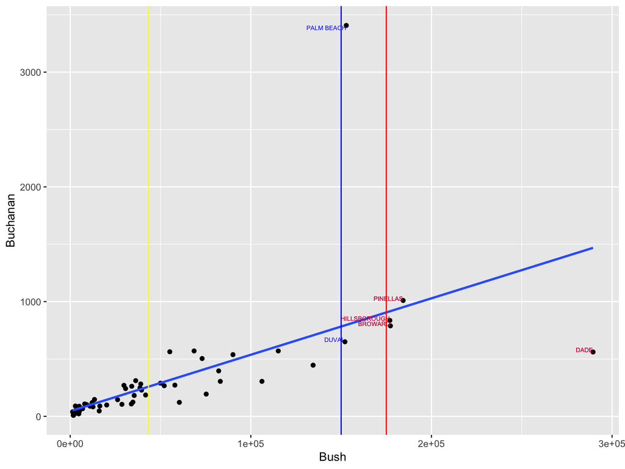

# Standardized and Studentized Residuals

- For outliers, we can check their role in a model with standardized or studentized residuals
  - Both use the leverage point
- Standardized residuals = $stndres_i = \frac{y_i-\hat{y}}{\hat{\sigma_\epsilon}\sqrt{1-h_i}}$
  - Remember, standardized generally means subtract the mean and divide by the standard deviation/error
  - $\hat{\sigma_\epsilon}$ is the regression standard deviation
- Studentized residual = $studres_i = \frac{y_i-\hat{y}}{\hat{\sigma_{(i)}}\sqrt{1-h_i}}$
  - $\hat{\sigma_{(i)}}$ = the standard deviation of the regression with observation $i$ excluded
- Moderate outliers have residuals beyond $\pm 2$, serious outliers have residuals beyond $\pm 3$

```r
resid<-PB_lm$resid
stnd_res<-PB_diag$std.res
stud_res<-PB_diag$stud.res
fitted<-PB_lm$fitted
county_resid<-cbind(PalmBeach,resid, stnd_res, stud_res, fitted)
county_resid%>%
  mutate(m_out_stnd=ifelse(abs(stnd_res)>2,"y","n"),
         s_out_stnd=ifelse(abs(stnd_res)>3,"y","n"),
         m_out_stud=ifelse(abs(stud_res)>2,"y","n"),
         s_out_stud=ifelse(abs(stud_res)>3,"y","n")) %>%
  filter(m_out_stnd=="y" | m_out_stud=="y")
```

```
##       County Buchanan   Bush     resid  stnd_res  stud_res    fitted m_out_stnd
## 1       DADE      561 289456 -907.4953 -3.059180 -3.280922 1468.4953          y
## 2 PALM BEACH     3407 152846 2610.1926  7.651072 24.080144  796.8074          y
##   s_out_stnd m_out_stud s_out_stud
## 1          y          y          y
## 2          y          y          y
```

And Visually:

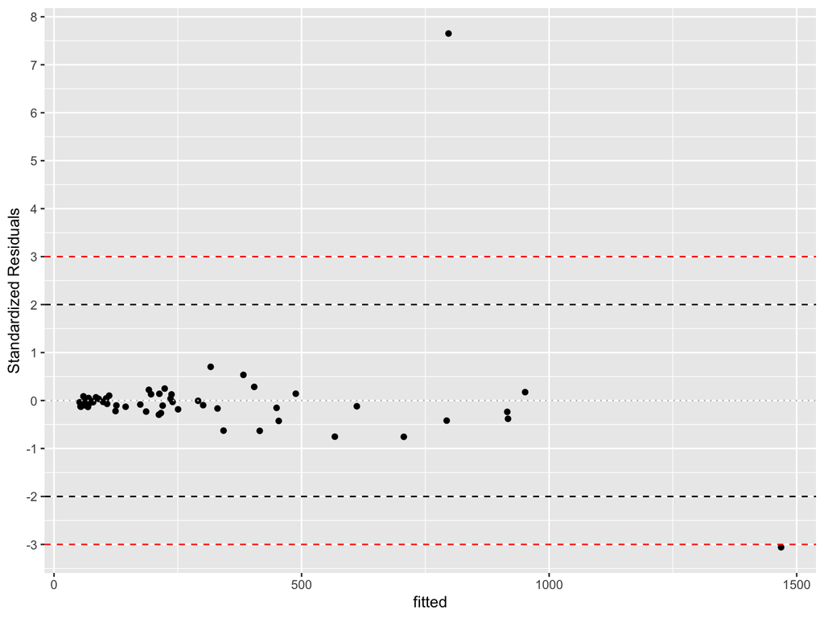

## Put this together - Cook’s Distance

- Cook’s Distance quantifies how much a given point influences the regression fit
  - It combines the role an outlier or an influence point could have
- Depends on:
  - how close the observation fits in the trend of the data (standardized / studentized residual)
  - how much leverage that observation has ($h_i$)

$D_i = {\frac{(stdres_i)^2}{k+1}}{(\frac{h_i}{1-h_i})}$

- Moderately influential cases have $D_i>0.5$ and very influential cases have $D_i>1$
- Remember, leverage for SLR is >4/n (moderately unusual) and >6/n (very unusual). Here, n=67
  - For MLR: >2(k+1)/n or >3(k+1)/n

```r
cooks<-PB_diag$cooks
county_cook<-cbind(PalmBeach,cooks)
county_cook%>%
  mutate(mod_inf=ifelse(cooks>0.5,"y","n"),
         ver_inf=ifelse(cooks>1,"y","n")) %>%
  filter(mod_inf=="y")
```

```
##       County Buchanan   Bush    cooks mod_inf ver_inf
## 1       DADE      561 289456 1.981366       y       y
## 2 PALM BEACH     3407 152846 2.231935       y       y
```

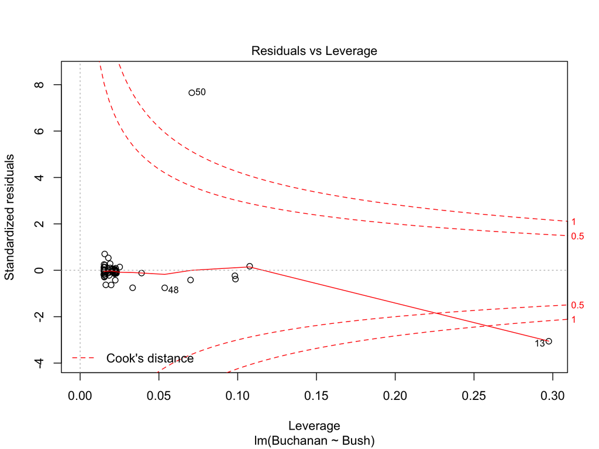

```r
plot(PB_lm, which=5)
```

# Caveats & Caution

The goal here is to identify points, not necessarily to delete them.